# Praktikum 5

### Step 2 Identifikasi Model

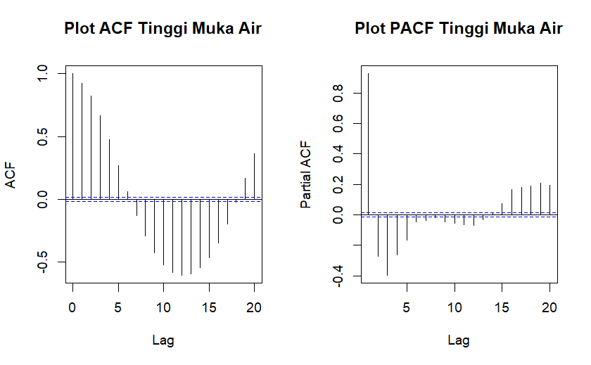

```r
#Identifikasi model melalui Plot ACF dan PACF
par(mfrow = c(1,2))
acf(dataTrain, main = "Plot ACF Tinggi Muka Air", lag.max=20)
pacf(dataTrain, main = "Plot PACF Tinggi Muka Air", lag.max=20)
```

### Step 3 Pendugaan Parameter

```r
#Fit Model
fit.ar1 <- Arima(dataTrain, order = c(1,0,0))
summary(fit.ar1)
```

```
Series: dataTrain
ARIMA(1,0,0) with non-zero mean

Coefficients:
         ar1     mean
      0.9268  187.308
s.e.  0.0029    0.979

sigma^2 = 86.98:  log likelihood = -61773.44
AIC=123552.9   AICc=123552.9   BIC=123576.1

Training set error measures:
                        ME     RMSE      MAE        MPE     MAPE      MASE      ACF1
Training set -0.0009118818 9.325748 6.791304 -0.2571143 3.685635 0.9893477 0.2505284
```

```r
fit.ar1$coef
```

```
        ar1   intercept
  0.9268124 187.3080282
```

```r
#t hitung untuk ar1
thit.ar1 <- fit.ar1$coef[1]/0.0029
thit.ar1
```

```
     ar1
319.5905
```

```r
p.value.ar1 = 2*pt(-abs(thit.ar1), df = length(dataTrain)-1)
p.value.ar1
```

```
ar1
  0
```

```r
#t hitung untuk intersep
thit.int <- fit.ar1$coef[2]/0.979
thit.int
```

```
intercept
 191.3259
```

```r
p.value.int = 2*pt(-abs(thit.int), df = length(dataTrain)-1)
p.value.int
```

```
intercept
        0
```

```r
auto.arima(dataTrain, trace = TRUE)
```

```
 Fitting models using approximations to speed things up...

 ARIMA(2,1,2) with drift         : 120560.6
 ARIMA(0,1,0) with drift         : 124168.1
 ARIMA(1,1,0) with drift         : 123301
 ARIMA(0,1,1) with drift         : 123634.4
 ARIMA(0,1,0)                    : 124166.1
 ARIMA(1,1,2) with drift         : 121085
 ARIMA(2,1,1) with drift         : 121425.6
 ARIMA(3,1,2) with drift         : 116301.7
 ARIMA(3,1,1) with drift         : 121347.7
 ARIMA(4,1,2) with drift         : 116303.6
 ARIMA(3,1,3) with drift         : 120337.1
 ARIMA(2,1,3) with drift         : 117666.4
 ARIMA(4,1,1) with drift         : Inf
 ARIMA(4,1,3) with drift         : 116304.2
 ARIMA(3,1,2)                    : 116299.8
 ARIMA(2,1,2)                    : 120558.6
 ARIMA(3,1,1)                    : 121345.7
 ARIMA(4,1,2)                    : 116301.6
 ARIMA(3,1,3)                    : 120335.2
 ARIMA(2,1,1)                    : 121423.6
 ARIMA(2,1,3)                    : 117664.5
 ARIMA(4,1,1)                    : Inf
 ARIMA(4,1,3)                    : 116302.2

 Now re-fitting the best model(s) without approximations...

 ARIMA(3,1,2)                    : 116279.4

 Best model: ARIMA(3,1,2)

Series: dataTrain
ARIMA(3,1,2)

Coefficients:
         ar1      ar2      ar3      ma1     ma2
      1.6930  -0.5620  -0.2117  -1.8730  0.8907
s.e.  0.0089   0.0162   0.0081   0.0054  0.0065

sigma^2 = 56.59:  log likelihood = -58133.71
AIC=116279.4   AICc=116279.4   BIC=116325.8
```

```r
lmtest::coeftest(fit.ar1)
```

```
z test of coefficients:

            Estimate Std. Error z value  Pr(>|z|)
ar1         0.926812   0.002885  321.25 < 2.2e-16 ***
intercept 187.308028   0.978977  191.33 < 2.2e-16 ***
---
Signif. codes:  0 ‘***’ 0.001 ‘**’ 0.01 ‘*’ 0.05 ‘.’ 0.1 ‘ ’ 1
```

### Step 4 Diagnostik Model

Diagnostik model dilakukan untuk mengetahui apakah sisaan dari model yang dibangun telah memenuhi asumsi pemodelan. Asumsi sisaan yang harus terpenuhi pada model ARIMA(p,d,q) adalah sebagai berikut:

Sisaan saling bebas (tidak ada autokorelasi) dan identik

Sisaan mengikuti sebaran Normal (0,σ2)

#### Eksploratif

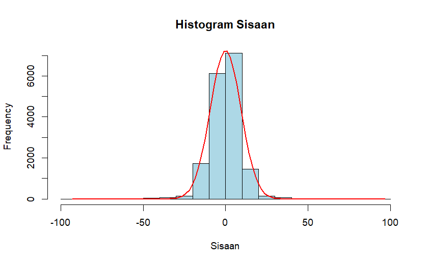

```r
#Plot Histogram sisaan
sisaan.model <- fit.ar1$residuals

#Eksplorasi
h <- hist(sisaan.model, col="lightblue", xlab="Sisaan", main="Histogram Sisaan")
xfit <- seq(min(sisaan.model), max(sisaan.model), length=100)
yfit <- dnorm(xfit,mean=mean(sisaan.model), sd=sd(sisaan.model))
yfit <- yfit*diff(h$mids[1:2]*length(sisaan.model))
lines(xfit, yfit, col="red", lwd=2)
```

```r
par(mfrow=c(1,2))
#Plot Q-Q
qqnorm(sisaan.model, ylab="Plot QQ Sisaan Model")
qqline(sisaan.model, col="red", lwd=2)
```

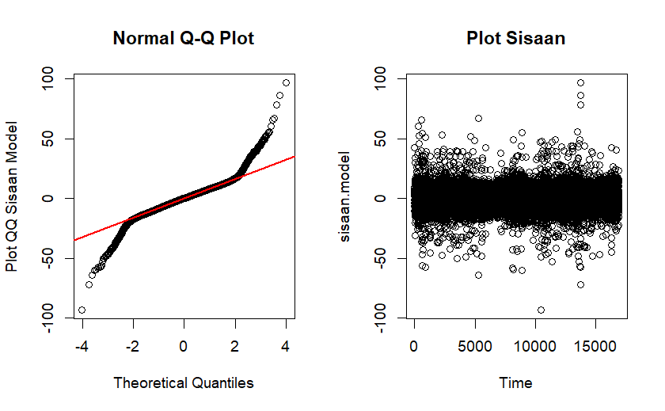

```r
#Plot sebaran sisaan
plot(sisaan.model, type="p", main="Plot Sisaan")
```

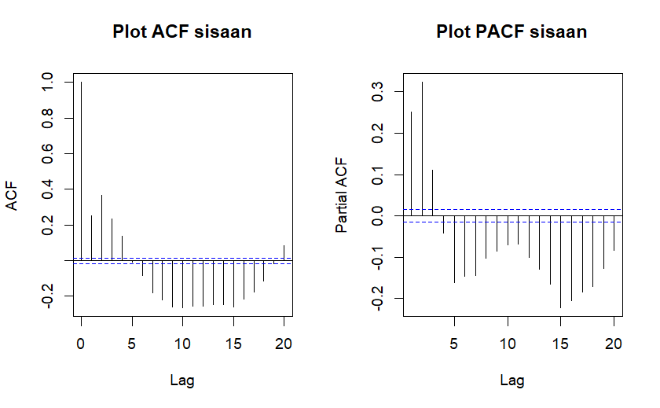

```r
#Plot ACF dan PACF sisaan Model
par(mfrow=c(1,2))
acf(sisaan.model, main = "Plot ACF sisaan", lag.max=20)
pacf(sisaan.model, main = "Plot PACF sisaan", lag.max=20)
```

```
    Ljung-Box test

data:  Residuals from ARIMA(1,0,0) with non-zero mean
Q* = 8356.2, df = 9, p-value < 2.2e-16

Model df: 1.   Total lags used: 10
```

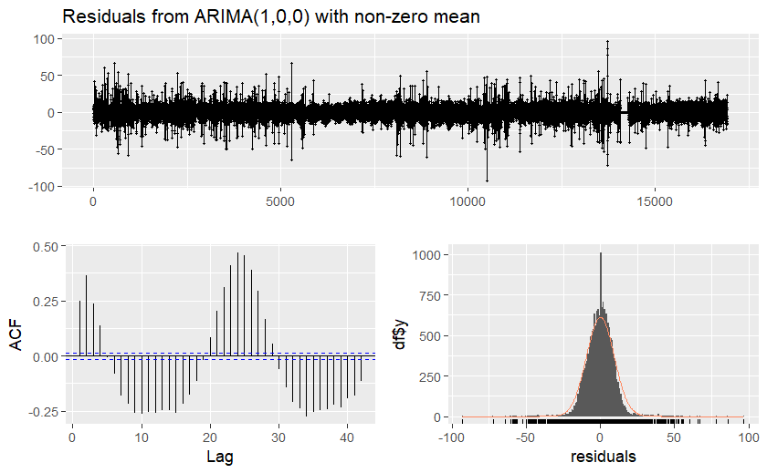

```r
checkresiduals(fit.ar1)
```

Uji Non-Autokorelasi dengan Ljung-Box test

Hipotesis:

**H0**

Sisaan saling bebas

**H1**

Sisaan tidak saling bebas

Keputusan: Tolak H0 jika p−value<α

```r
#L-Jung Box test
test <- Box.test(sisaan.model, lag = 24, type = "Ljung")
test
```

```
    Box-Ljung test

data:  sisaan.model
X-squared = 24347, df = 24, p-value < 2.2e-16
```

Berdasarkan hasil uji Ljung-Box di atas dapat dilihat bahwa Berhasil tolak H0 karena diperoleh p-value = 2.2e-16 yang berarti terdapat gejala autokorelasi pada sisaan dari model ARIMA (1,0,0) atau antar et berkorelasi.

```r
library(tseries)
jarque.bera.test(residuals(fit.ar1))
```

```
    Jarque Bera Test

data:  residuals(fit.ar1)
X-squared = 27658, df = 2, p-value < 2.2e-16
```

Berdasarkan hasil uji normalitas di atas dapat disimpulkan bahwa H0 berhasil ditolak sehingga sisaan dari model ARIMA (1,0,0) tidak mengikuti sebaran Normal.

### Step 5 Overfitting

#### Pendugaan Parameter: Model AR(2)

```r
fit.ar2 <- Arima(dataTrain, order = c(2,0,0))
summary(fit.ar2)
```

```
Series: dataTrain
ARIMA(2,0,0) with non-zero mean

Coefficients:
         ar1      ar2      mean
      1.1773  -0.2703  187.3081
s.e.  0.0074   0.0074    0.7419

sigma^2 = 80.63:  log likelihood = -61131.72
AIC=122271.4   AICc=122271.4   BIC=122302.4

Training set error measures:
                        ME    RMSE      MAE        MPE     MAPE     MASE       ACF1
Training set -0.0006963721 8.97856 6.017747 -0.2379595 3.265419 0.876657 -0.1070973
```

```r
fit.ar2$coef[1:3]
```

```
        ar1         ar2   intercept
  1.1772956  -0.2703098 187.3080563
```

```r
#t hitung untuk koef ar1
thit.ar1 <- fit.ar2$coef[1]/0.0074
thit.ar1
```

```
    ar1
159.094
```

```r
p.value.ar1 = 2*pt(-abs(thit.ar1), df=length(dataTrain)-1)
p.value.ar1
```

```
ar1
  0
```

```r
#t hitung untuk koef ar1
thit.ar2 <- fit.ar2$coef[2]/0.0074
thit.ar2
```

```
      ar2
-36.52835
```

```r
p.value.ar2 = 2*pt(-abs(thit.ar2), df=length(dataTrain)-1)
p.value.ar2
```

```
        ar2
2.9653e-281
```

```r
#t hitung untuk intersep
thit.int <- fit.ar2$coef[3]/0.7419
thit.int
```

```
intercept
 252.4708
```

```r
p.value.int <- 2*pt(-abs(thit.int), df=length(dataTrain)-1)
p.value.int
```

```
intercept
        0
```

```r
#Fit Model
fit.ar1 <- Arima(dataTrain, order = c(1,0,0))
summary(fit.ar1)
```

```
Series: dataTrain
ARIMA(1,0,0) with non-zero mean

Coefficients:
         ar1     mean
      0.9268  187.308
s.e.  0.0029    0.979

sigma^2 = 86.98:  log likelihood = -61773.44
AIC=123552.9   AICc=123552.9   BIC=123576.1

Training set error measures:
                        ME     RMSE      MAE        MPE     MAPE      MASE      ACF1
Training set -0.0009118818 9.325748 6.791304 -0.2571143 3.685635 0.9893477 0.2505284
```

```r
lmtest::coeftest(fit.ar1)
```

```
z test of coefficients:

            Estimate Std. Error z value  Pr(>|z|)
ar1         0.926812   0.002885  321.25 < 2.2e-16 ***
intercept 187.308028   0.978977  191.33 < 2.2e-16 ***
---
Signif. codes:  0 ‘***’ 0.001 ‘**’ 0.01 ‘*’ 0.05 ‘.’ 0.1 ‘ ’ 1
```

```r
#Overfitting
fit.ar2 <- Arima(dataTrain, order = c(2,0,0))
summary(fit.ar2)
```

```
Series: dataTrain
ARIMA(2,0,0) with non-zero mean

Coefficients:
         ar1      ar2      mean
      1.1773  -0.2703  187.3081
s.e.  0.0074   0.0074    0.7419

sigma^2 = 80.63:  log likelihood = -61131.72
AIC=122271.4   AICc=122271.4   BIC=122302.4

Training set error measures:
                        ME    RMSE      MAE        MPE     MAPE     MASE       ACF1
Training set -0.0006963721 8.97856 6.017747 -0.2379595 3.265419 0.876657 -0.1070973
```

```r
lmtest::coeftest(fit.ar2)
```

```
z test of coefficients:

             Estimate  Std. Error z value  Pr(>|z|)
ar1         1.1772956   0.0074029 159.031 < 2.2e-16 ***
ar2        -0.2703098   0.0074046 -36.506 < 2.2e-16 ***
intercept 187.3080563   0.7418825 252.477 < 2.2e-16 ***
---
Signif. codes:  0 ‘***’ 0.001 ‘**’ 0.01 ‘*’ 0.05 ‘.’ 0.1 ‘ ’ 1
```

Validasi Model

```r
#plot dugaan dengan data asli
dugaan.ar1 <- fitted(fit.ar1)
dugaan.ar2 <- fitted(fit.ar2)
cbind(dataTrain,dugaan.ar1,dugaan.ar2)
```

```
Time Series:
Start = 1
End = 16916
Frequency = 1
      dataTrain dugaan.ar1 dugaan.ar2
    1  170.0000   176.4996  176.25904
    2  161.0000   171.2667  170.88511
    3  172.0000   162.9254  161.01423
    4  177.0000   173.1204  176.39727
    5  181.0000   177.7544  179.31034
    6  188.0000   181.4617  182.66798
    7  187.0000   187.9494  189.82781
    8  192.0000   187.0225  186.75834
    9  194.0000   191.6566  192.91513
   10  236.0000   193.5102  193.91817
```

[output cut: 324 more lines]

```r
ts.plot(dataTrain,xlab="periode waktu",ylab="Bagi hasil",  col="blue",lty=3)
points(dataTrain)
```

```r
lines (dugaan.ar1,col="red",lwd=2)
lines (dugaan.ar2,col="black",lwd= 2)
```

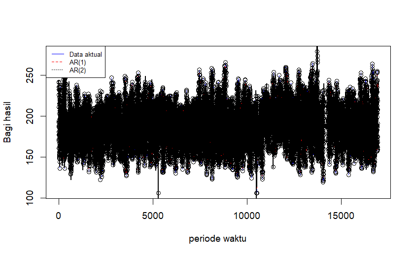

```r
legend("topleft",legend=c("Data aktual","AR(1)","AR(2)"),
       lty=1:3,col=c ("blue","red","black"), cex=0.7)
```

```r
forecast.ar1 <- forecast(dataTrain, model = fit.ar1, h=6)
forecast.ar1
```

|  | Point Forecast | Lo 80 | Hi 80 | Lo 95 | Hi 95 |
| --- | --- | --- | --- | --- | --- |
| 16917 | 161.0718 | 149.1197 | 173.0239 | 142.7926 | 179.3510 |
| 16918 | 162.9920 | 146.6959 | 179.2880 | 138.0693 | 187.9147 |
| 16919 | 164.7716 | 145.5111 | 184.0321 | 135.3152 | 194.2280 |
| 16920 | 166.4210 | 144.9383 | 187.9037 | 133.5660 | 199.2759 |
| 16921 | 167.9497 | 144.7273 | 191.1720 | 132.4341 | 203.4652 |
| 16922 | 169.3665 | 144.7477 | 193.9852 | 131.7153 | 207.0176 |

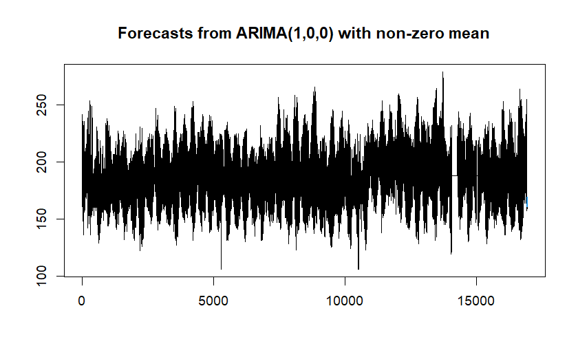

```r
plot(forecast.ar1)
```

```r
accuracy(forecast.ar1, dataTest)
```

```
                        ME     RMSE      MAE        MPE     MAPE      MASE      ACF1 Theil's U
Training set -0.0009118818 9.325748 6.791304 -0.2571143 3.685635 0.9893477 0.2505284        NA
Test set      2.4045891673 5.475135 4.683043  1.3047588 2.724714 0.6822193 0.5600253  1.244816
```

### Step 6 Peramalan

```r
#Forecast
fit.ar1 <- arima(tma, order=c(1,0,0))
forecast.tma <- forecast(tma, model = fit.ar1, h=6)
forecast.tma
```

|  | Point Forecast | Lo 80 | Hi 80 | Lo 95 | Hi 95 |
| --- | --- | --- | --- | --- | --- |
| 21146 | 201.9517 | 190.1845 | 213.7189 | 183.9553 | 219.9481 |
| 21147 | 200.9742 | 184.8850 | 217.0634 | 176.3679 | 225.5805 |
| 21148 | 200.0627 | 180.9959 | 219.1295 | 170.9026 | 229.2229 |
| 21149 | 199.2128 | 177.8924 | 220.5332 | 166.6060 | 231.8196 |
| 21150 | 198.4203 | 175.3183 | 221.5222 | 163.0889 | 233.7517 |
| 21151 | 197.6813 | 173.1352 | 222.2274 | 160.1413 | 235.2213 |

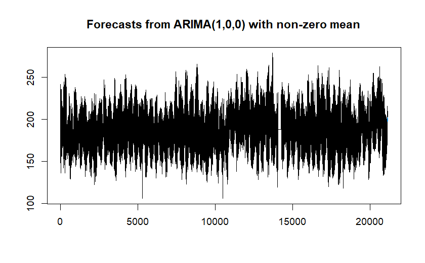

```r
plot(forecast.tma)
```